# R_Final_Project

Ela Yenikoylu

11/28/2018

## Tools and packages used for this analysis

```r
library(tidyverse)
library(plyr)
```

```r
library(dplyr)
library(ggplot2)
```

## Loading the data

### We need to start with reading the csv file.

```r
atp_tennis <- read.csv("tournaments.csv",  header=TRUE, stringsAsFactors=FALSE, na.strings=c(""))
dim(atp_tennis)
```

```
## [1] 4114   28
```

## Data Pre-Processing

### Before we start analysis, need to make sure that data is consistent, and clean.

### There are some columns that not related the purpose of our analysis. For example doubles data, or the tournement and player IDs, url suffixes etc. We can start cleaning our data by removing these.

```r
tennis <- atp_tennis[, !(colnames(atp_tennis) %in% c("tourney_order", "tourney_name", "tourney_id", "tourney_dates", "tourney_month", "tourney_day", "tourney_doubles_draw", "tourney_fin_commit", "tourney_url_suffix", "singles_winner_url", "singles_winner_player_slug", "singles_winner_player_id", "doubles_winner_1_name", "doubles_winner_1_url", "doubles_winner_1_player_slug", "doubles_winner_1_player_id", "doubles_winner_2_name", "doubles_winner_2_url", "doubles_winner_2_player_slug", "doubles_winner_2_player_id", "tourney_year_id"))]

tennis <- na.omit(tennis)

dim(tennis)
```

```
## [1] 3984    7
```

### Now it’s time to make the colnames more consistent and readable.

```r
colnames(tennis) <- c("year", "name", "location", "singles_draw", "conditions", "surface", "winner_name" )
colnames(tennis)
```

```
## [1] "year"         "name"         "location"     "singles_draw"
## [5] "conditions"   "surface"      "winner_name"
```

### Let’s check the part of the data and see how it looks now.

```r
head(tennis)
```

```
##   year      name               location singles_draw conditions surface
## 1 1877 wimbledon  London, Great Britain           32    Outdoor   Grass
## 2 1878 wimbledon  London, Great Britain           64    Outdoor   Grass
## 3 1879 wimbledon  London, Great Britain           64    Outdoor   Grass
## 4 1880 wimbledon  London, Great Britain           64    Outdoor   Grass
## 5 1881 wimbledon  London, Great Britain           64    Outdoor   Grass
## 6 1881   us-open Newport, United States           32    Outdoor   Grass
##       winner_name
## 1    Spencer Gore
## 2     Frank Hadow
## 3    John Hartley
## 4    John Hartley
## 5 William Renshaw
## 6    William Glyn
```

### For the future analysis, setting some variables as factors needed.

```r
tennis$name <- as.factor(tennis$name)
tennis$location <- as.factor(tennis$locatio)
tennis$conditions <- as.factor(tennis$conditions)
tennis$surface <- as.factor(tennis$surface)
tennis$winner_name <- as.factor(tennis$winner_name)
```

### Now we can use summarry function to see some insights from our pre-processed data.

```r
summary(tennis)
```

```
##       year                   name                         location
##  Min.   :1877   us-open        : 137   London, Great Britain  : 104
##  1st Qu.:1978   wimbledon      : 131   London                 :  96
##  Median :1990   australian-open: 104   Paris                  :  81
##  Mean   :1988   roland-garros  :  87   Sydney                 :  62
##  3rd Qu.:2002   houston        :  72   New York, United States:  57
##  Max.   :2017   kitzbuhel      :  71   Tokyo                  :  56
##                 (Other)        :3382   (Other)                :3528
##   singles_draw      conditions     surface             winner_name
##  Min.   :  4.00   Indoor :1024   Carpet: 562   Jimmy Connors : 110
##  1st Qu.: 32.00   Outdoor:2960   Clay  :1347   Ivan Lendl    :  90
##  Median : 32.00                  Grass : 565   Roger Federer :  90
##  Mean   : 46.18                  Hard  :1510   John McEnroe  :  75
##  3rd Qu.: 56.00                                Rafael Nadal  :  75
##  Max.   :256.00                                Novak Djokovic:  67
##                                                (Other)       :3477
```

### Using str function will give us some more insights.

```r
str(tennis)
```

```
## 'data.frame':    3984 obs. of  7 variables:
##  $ year        : int  1877 1878 1879 1880 1881 1881 1882 1882 1883 1883 ...
##  $ name        : Factor w/ 274 levels "acapulco","adelaide",..: 270 270 270 270 270 259 270 259 270 259 ...
##  $ location    : Factor w/ 406 levels "Acapulco","Acapulco, Mexico",..: 200 200 200 200 200 266 200 266 200 266 ...
##  $ singles_draw: int  32 64 64 64 64 32 32 64 32 32 ...
##  $ conditions  : Factor w/ 2 levels "Indoor","Outdoor": 2 2 2 2 2 2 2 2 2 2 ...
##  $ surface     : Factor w/ 4 levels "Carpet","Clay",..: 3 3 3 3 3 3 3 3 3 3 ...
##  $ winner_name : Factor w/ 623 levels "Aaron Krickstein",..: 549 172 299 299 612 610 612 100 612 255 ...
##  - attr(*, "na.action")= 'omit' Named int  269 293 298 371 372 385 401 402 415 435 ...
##   ..- attr(*, "names")= chr  "269" "293" "298" "371" ...
```

## Now we are good to go for our analysis. Considering our research objectives, we will be moving forward question by question.

### How many atp tournements in each year? and which year has most ATP tournaments?

```r
max_atp <- tennis %>%
  group_by(year) %>%
  dplyr::summarize(number_of_tournaments = n()) %>%
  arrange(desc(number_of_tournaments))

max_atp
```

```
## # A tibble: 141 x 2
##     year number_of_tournaments
##    <int>                 <int>
##  1  1982                   102
##  2  1976                   100
##  3  1977                   100
##  4  1980                    98
##  5  1973                    94
##  6  1974                    94
##  7  1975                    93
##  8  1979                    93
##  9  1978                    92
## 10  1981                    90
## # ... with 131 more rows
```

### How many of them indoor, how many of them outdoor tournaments?

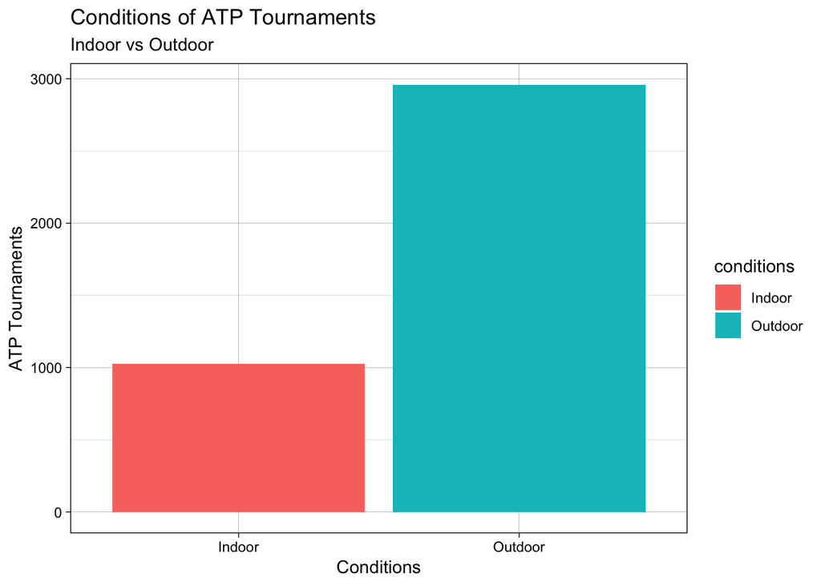

```r
tennis %>%
  group_by(conditions) %>%
  ggplot() +
  stat_count(aes(conditions, fill = conditions)) + labs(title = "Conditions of ATP Tournaments", subtitle = "Indoor vs Outdoor", y = "ATP Tournaments", x = "Conditions") + theme_linedraw()
```

### What kind of surface usually had been played on in the tournaments?

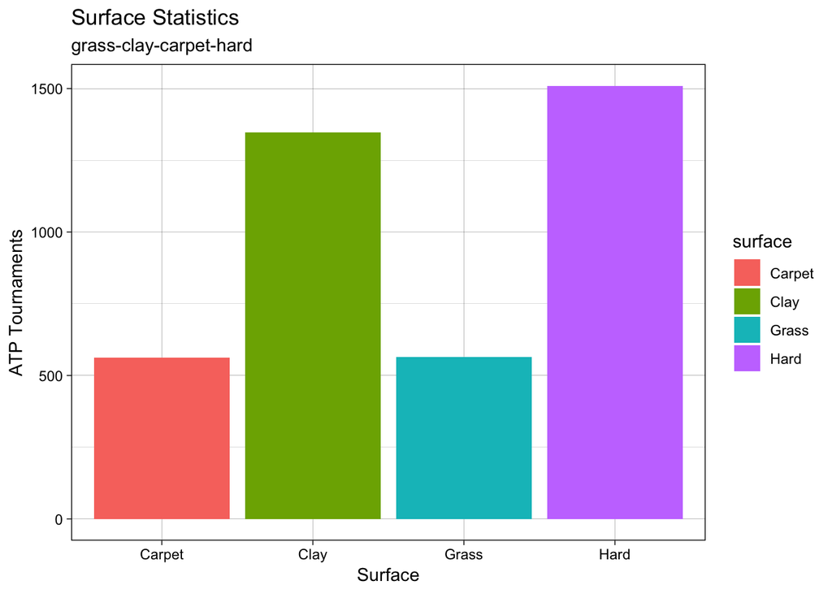

```r
tennis %>%
  group_by(surface) %>%
  ggplot() +
  stat_count(aes(surface, fill = surface)) + labs(title = "Surface Statistics", subtitle = "grass-clay-carpet-hard", y = "ATP Tournaments", x = "Surface") + theme_linedraw()
```

### Who is in the top 10 most successfull players in the ATP history.

```r
top_10 <- tennis %>%
  group_by(winner_name) %>%
  dplyr::summarize(number_of_wins = n()) %>%
  arrange(desc(number_of_wins)) %>%
  head(10)

top_10
```

```
## # A tibble: 10 x 2
##    winner_name     number_of_wins
##    <fct>                    <int>
##  1 Jimmy Connors              110
##  2 Ivan Lendl                  90
##  3 Roger Federer               90
##  4 John McEnroe                75
##  5 Rafael Nadal                75
##  6 Novak Djokovic              67
##  7 Bjorn Borg                  61
##  8 Guillermo Vilas             61
##  9 Andre Agassi                59
## 10 Pete Sampras                59
```

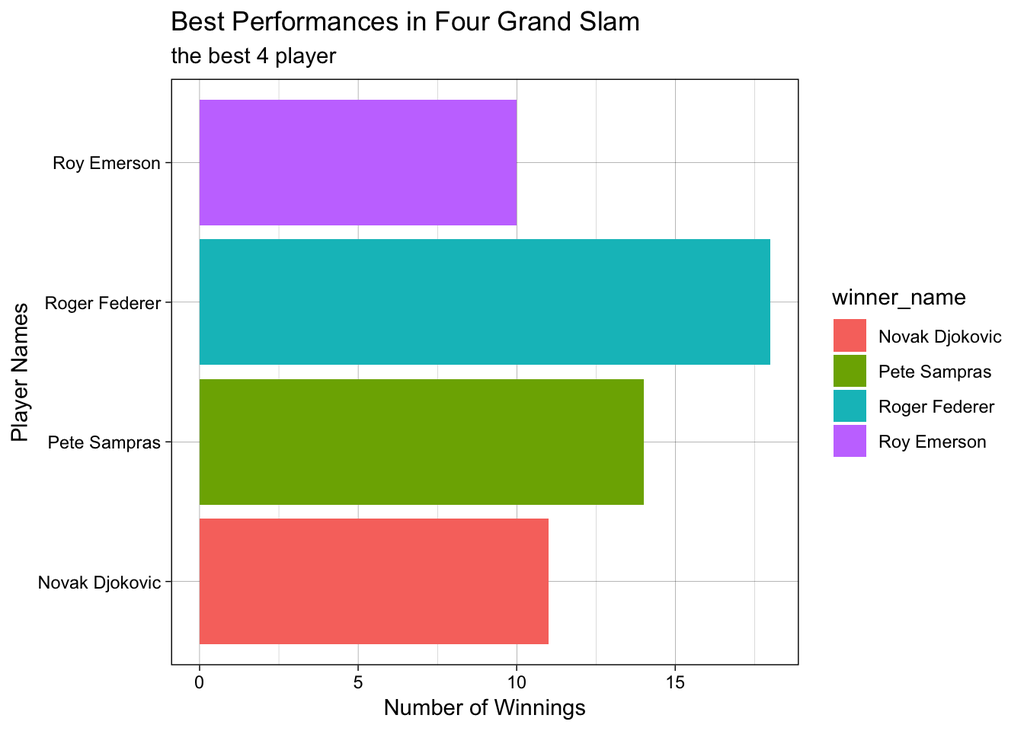

```r
grand_slams <- c("us-open", "wimbledon", "rolland-garros", "australian-open")

tennis %>%
  filter(name %in% grand_slams) %>%
  group_by(winner_name) %>%
  filter(n() >= 10) %>%
  ggplot() +
  geom_bar(aes(winner_name, fill = winner_name)) + coord_flip() + labs(title = "Best Performances in Four Grand Slam", subtitle = "the best 4 player", y = "Number of Winnings", x = "Player Names") + theme_linedraw()
```

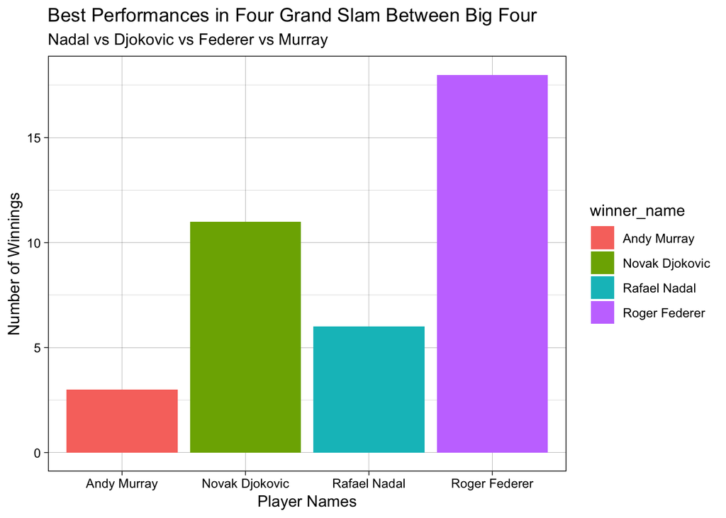

```r
big_four <- c("Novak Djokovic", "Rafael Nadal", "Roger Federer", "Andy Murray")

tennis %>%
  filter(name %in% grand_slams) %>%
  group_by(winner_name) %>%
  filter(winner_name %in% big_four) %>%
  ggplot() +
  geom_bar(aes(winner_name, fill = winner_name)) + labs(title = "Best Performances in Four Grand Slam Between Big Four", subtitle = "Nadal vs Djokovic vs Federer vs Murray", y = "Number of Winnings", x = "Player Names") + theme_linedraw()
```

### How is the Big Four’s performances in different surfaces?

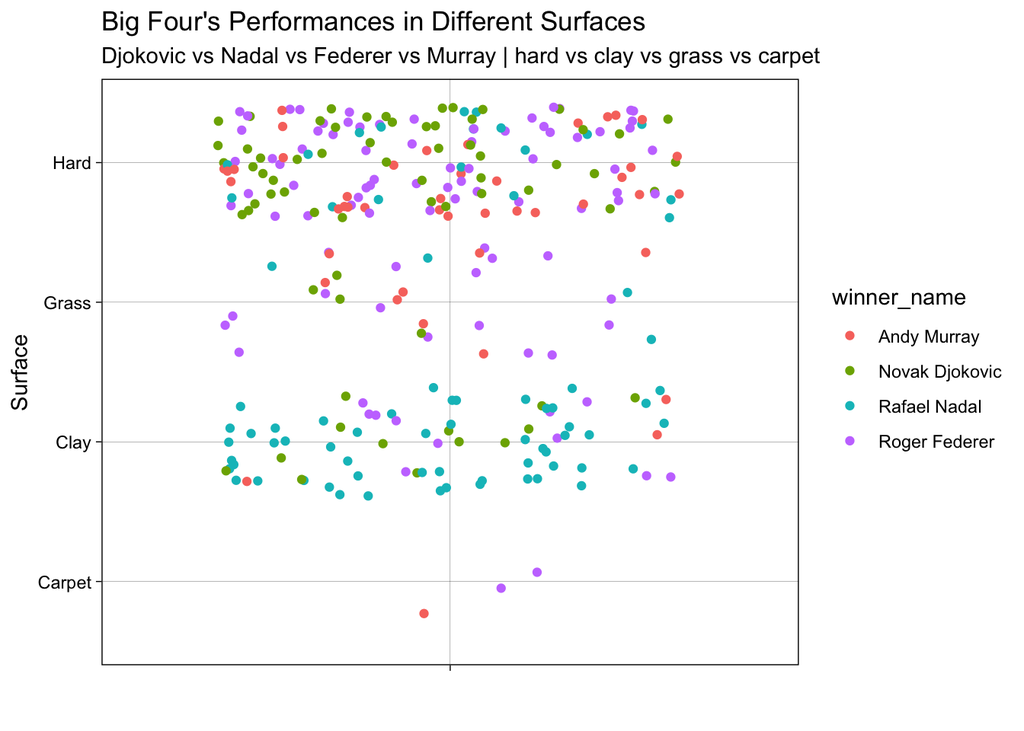

```r
tennis %>%
  filter(winner_name %in% big_four) %>%
  group_by(surface) %>%
  ggplot(aes(x = "", y = surface)) +
  geom_jitter(aes(color = winner_name)) + labs(title = "Big Four's Performances in Different Surfaces", subtitle = "Djokovic vs Nadal vs Federer vs Murray | hard vs clay vs grass vs carpet", x = "", y = "Surface") + theme_linedraw()
```

### How is the competition between Rafael Nadal and Novak Djokovic in the clay surface?

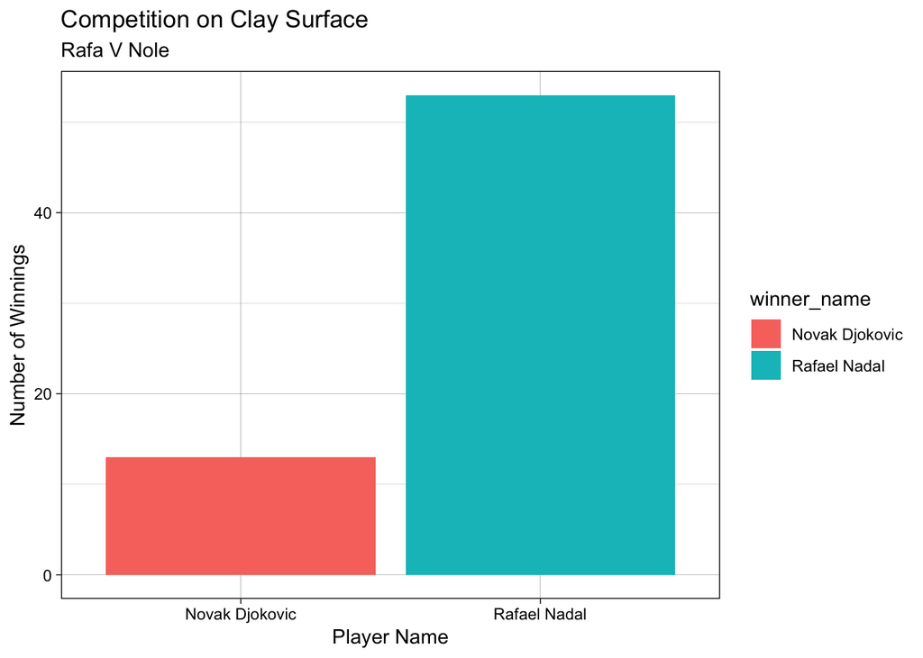

```r
rafa_nole <- c("Novak Djokovic", "Rafael Nadal")

tennis %>%
  filter(winner_name %in% rafa_nole) %>%
  group_by(winner_name) %>%
  filter(surface == "Clay") %>%
  ggplot() +
  geom_bar(aes(winner_name, fill = winner_name)) + labs(title = "Competition on Clay Surface", subtitle = "Rafa V Nole", x = "Player Name", y = "Number of Winnings") + theme_linedraw()
```

### How is the competition between Rafael Nadal and Novak Djokovic in the hard surface?

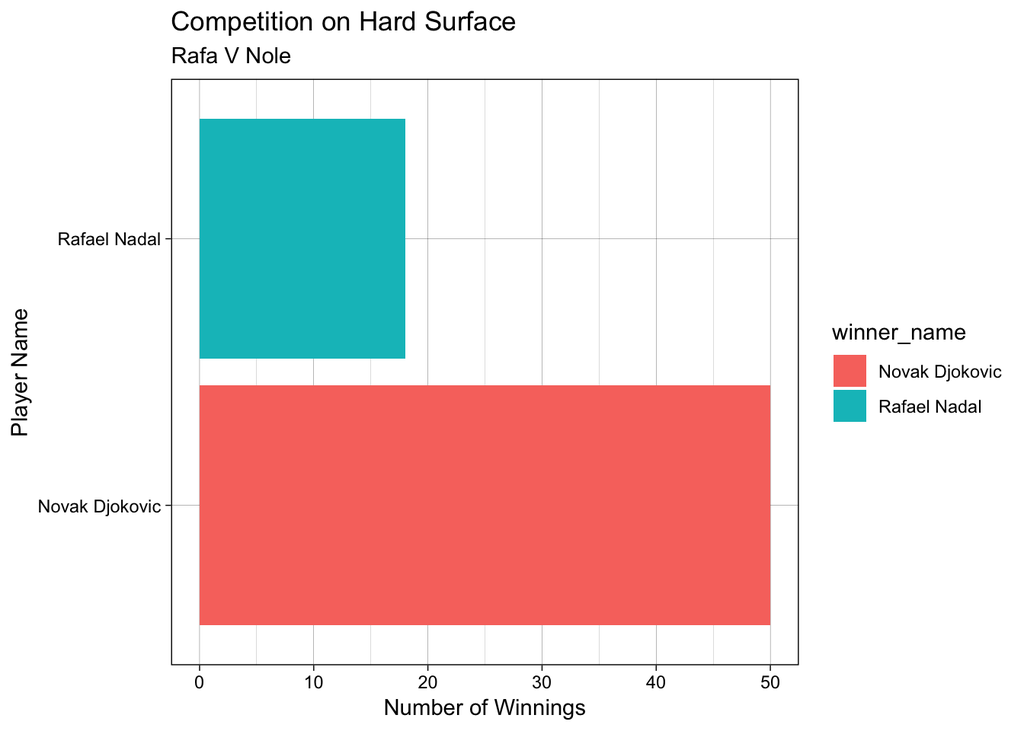

```r
tennis %>%
  filter(winner_name %in% rafa_nole) %>%
  group_by(winner_name) %>%
  filter(surface == "Hard") %>%
  ggplot() +
  geom_bar(aes(winner_name, fill = winner_name)) + coord_flip() + labs(title = "Competition on Hard Surface", subtitle = "Rafa V Nole", x = "Player Name", y = "Number of Winnings") + theme_linedraw()
```